# CreditMetric_model

Olga Sieradzan

2025-03-13

```r
library(foreign)
library(dplyr)
library(cowplot)
library(ggplot2)
library(readr)
library(readxl)
library(MASS)
database <- read_excel("C:/Users/olgas/OneDrive/Documents/GitHub/Quantative-risk-models-summit/dane_cm.xlsx", sheet = "dane")
trans <- read_excel("C:/Users/olgas/OneDrive/Documents/GitHub/Quantative-risk-models-summit/dane_cm.xlsx", sheet = "trans")
```

# Wstęp

Kluczowym elementem działania na rynku jest znajomośc ryzyka. Jednym z rodzajów ryzyk z jakimi możemy się spotkać jest **ryzyko kredytowe**, natomiast jednym ze sposobów oceny poziomu takowego ryzyka są **ratingi**. Ich głowną ideą jest obiektywne i stabilne ocenianie ryzyka związanego z inwestycją. Zewnetrzne firmy ratingowe dokonują oceny przedsiębiorstwa i nadają mu rating. W S&P i Fitch, będą to oceny : AAA, AA, A, BBB, BB, B, CCC, D oraz oceny pośrednie np. AA- . Inne firmy stosują różne oznaczenia ale są one porównywalne do wyżej przedstawionego systemu ocen.

Pokrewnym zagadnieniem do ratingów i ryzyka kredytowego jest model **CreditMetrics**. Model CreditMetrics to szeroko stosowane narzędzie do pomiaeru ryzyka kredytowego w portfelach inwestycyjnych. Jego główna idea polega na symulacji zmian wartości portfela instrumentów dłużnych w wyniku zmian ratingu kredytowego lub niewypłacalności emitentów. Model wykorzystuje podejście oparte na wartości zagrożonej (VaR) do oszacowania potencjalnych strat w portfelu. Model CreditMetrics uwzględnia takie zmienne jak :

- Rating kredytowe
- Macierz przejść ratingowych
- Wartość instrumentu w zależności od ratingu
- Korelacje między eminentami

Celem badania jest oszacowanie ryzyka kredytowego portfela składającego się z trzech obligacji skarbowych o różnych ratingach oraz parametrach przy wykorzystaniu modelu CreditMetrics. Dodatkowo, analiza ma na celu zbadanie, jak zmienią się wyniki, jeśli założymy brak korelacji między inwestycjami, co pozwoli na ocenę wpływu dywersyfikacji ryzyka na stabilność portfela.

# Opis danych

Do badani zostanie zbudowany portefel z 3 obligacji skarbowych:

- 3-letnia obligacja o ratingu A (cena wykupu 100 000 zł, subordinated),
- 5-letnia obligacja o ratingu B (cena wykupu 50 000 zł, roczne kupony 5000 zł, senior secured),
- 2-letnia obligacja o ratingu CCC (cena wykupu 50 000 zł, roczne kupony 10 000 zł, senior unsecured).

## Macierz korelacji

Na sam początek, do głownej części badania, zostanie przyjęte założenie że macierz korelacji wyglada w poniżej pokazany sposób:

```r
obligacje <- data.frame(
  rating = c("A", "B", "CCC"),
  cena_wykupu = c(100000, 50000, 50000),
  kupon = c(0,5000, 10000),
  czas_trwania = c(3, 5, 2),
  typ = c("subordinated", "senior secured", "senior unsecured")
)

recovery_rate <- data.frame (
  klasa = c("subordinated", "senior secured", "senior unsecured"),
  stopa = c(0.3274, 0.538, 0.5113)
)

stopy_zwrotu <- data.frame(
  Rating = c( "A", "B", "CCC"),
  Year1 = c( 0.0372,  0.0605, 0.1505),
  Year2 = c( 0.0432,  0.0702, 0.1502),
  Year3 = c( 0.0493,  0.0803, 0.1403),
  Year4 = c( 0.0532,  0.0852, 0.1352)
)

cor_matrix <- matrix(c(1, 0.2, 0.15,
                       0.2, 1, 0.4,
                       0.15, 0.4, 1), nrow = 3)
p <- as.data.frame(cor_matrix)
rownames(p) <- c(c("V1", "V2", "V3"))
p
```

|  | V1 | V2 | V3 |
| --- | --- | --- | --- |
| V1 | 1.00 | 0.2 | 0.15 |
| V2 | 0.20 | 1.0 | 0.40 |
| V3 | 0.15 | 0.4 | 1.00 |

## Stopy zwrotu

W badaniu użyto stóp zwrotu zwizualizowanych na poniższym wykresie:

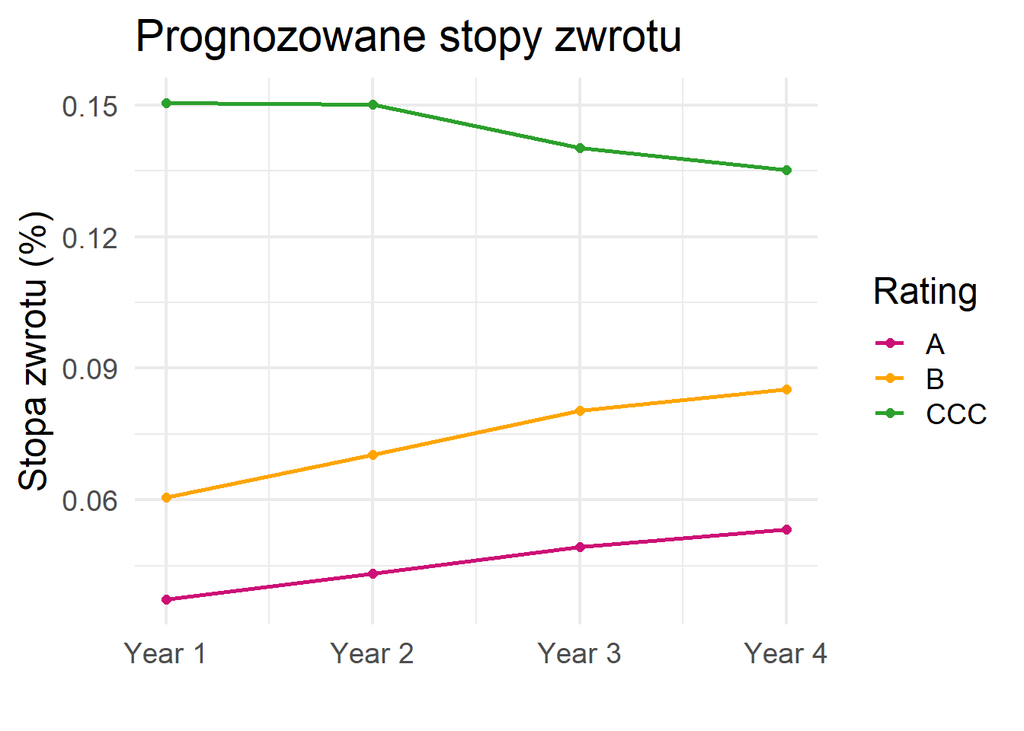

```r
library(tidyr)
stopy_zwrotu_long <- pivot_longer(stopy_zwrotu, cols = starts_with("Year"), names_to = "Year", values_to = "StopaZwrotu")

stopy_zwrotu_long$Year <- as.numeric(gsub("Year", "", stopy_zwrotu_long$Year))

 ggplot(stopy_zwrotu_long, aes(x = Year, y = StopaZwrotu, color = Rating, group = Rating)) +
  geom_line(size = 1) +  # Linie dla każdego ratingu
  geom_point(size = 2) +  # Punkty na wykresie
  labs(
    title = "Prognozowane stopy zwrotu",
    x = "",
    y = "Stopa zwrotu (%)",
    color = "Rating"
  ) +
  theme_minimal(base_size = 18) +
  scale_x_continuous(breaks = 1:4, labels = c("Year 1", "Year 2", "Year 3", "Year 4")) +
   scale_color_manual(values = c("A" = "#CD1076", "B" = "orange", "CCC" = "#2ca02c")) # Zakres osi Y
```

Warto zauważyć różnice w zachowaniu stóp zwrotu dla wybranych w badaniu ratingów. Ratingi A i B wykazują obiecująca tendencje do rośnięcia w czasie natomiast inwestycja w obligacje skarbowe o ratingu CCC, pomimo że na początku przyniesie większe zyski to z czasem zaczyna tracić a nie rosnąć.

## Stopa odzysku

W badaniu założono również że w przypadku gdy obligacja dostanie rating D, inwestor ma zagwarantowaną stopę odzysku. Wartości stóp odzysku rozważanych w badaniu zwizualizowano na poniższym wykresie:

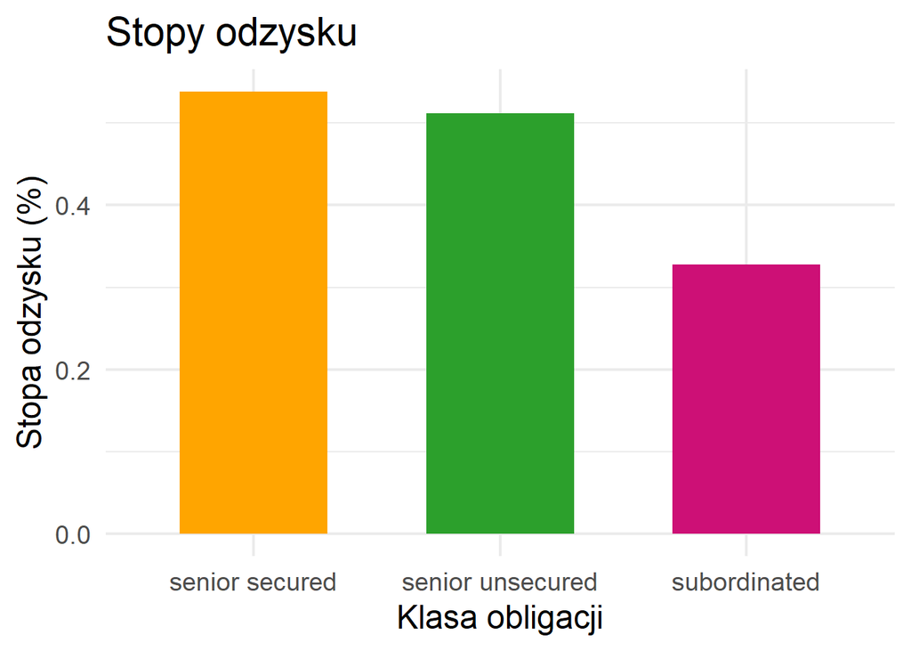

```r
ggplot(recovery_rate, aes(x = klasa, y = stopa, fill = klasa)) +
  geom_bar(stat = "identity", width = 0.6) +  # Wykres słupkowy
  labs(
    title = "Stopy odzysku ",
    x = "Klasa obligacji",
    y = "Stopa odzysku (%)",
    fill = "Klasa obligacji",
    legend = NULL
  ) +
  theme_minimal(base_size = 18) +  # Minimalistyczny styl wykresu
  scale_fill_manual(values = c("subordinated" = "#CD1076", "senior secured" = "orange", "senior unsecured" = "#2ca02c")) +  # Kolory słupków
  theme(legend.position = "none")
```

Im wyższa klasa (kategoria obligacji, która różni się poziomem ryzyka i priorytetem w przypadku niewypłacalności emitenta), tym wyższa stopa odzysku z inwestycji, co jest jak najbardziej intuicyjne.

## Macierz tranzycji

Kolejnym elementem kluczowym w modelu CreditMetric jest macierz tranzycji, która opisuje prawdopodobieństwo że obligacja z zadanego ratingu zmieni swój rating na inny. Poniżej zaprezentowano przyjętą do badania macierz tranzycji.

```r
database
```

| ...1 | V1 | V2 | V3 |
| --- | --- | --- | --- |
| AAA | 0.0064 | 0.0000 | 0.0000 |
| AA | 0.0746 | 0.0001 | 0.0000 |
| A | 0.9244 | 0.0012 | 0.0001 |
| BBB | 0.0551 | 0.0071 | 0.0008 |
| BB | 0.0042 | 0.0591 | 0.0024 |
| B | 0.0013 | 0.8422 | 0.0191 |
| CCC | 0.0000 | 0.0408 | 0.6920 |
| D | 0.0000 | 0.0000 | 0.0000 |

## Kupony

Ostatecznie obligacje skarbowe 2 i 3, mają kupony (płatności odestekowe, które emitent obligacji regularnie wypłaca posiadaczowi obligacji), w wysokości 5 000 zł oraz 10 000 zł.

Powyższy opis danych udowadnia że do badania przyjęto obligacje skarbowe, które mają między sobie różnice

## Wartośc bierząca obligacji

Wartośc bieżącą obligacji obliczono za pomocą poniższego wzoru

$PV = \sum_{t=1}^{T} \frac{K}{(1 + YTM)^t} + \frac{C}{(1 + YTM)^T}$

Gdzie:

- YTM to stopa zwroyu z odpowiedniego okresu
- K to kupon
- C to cena wykupu
- T to czas trwania obligacji

Według dokumentacji CreditMetrics, dyskontowi nie podlega kwota w pierwszym roku, tylko w pozostałych. Stąd w tabeli ze stopami zwrotu rozważane są tylko 4 wartości.

W ponizszej tabeli zaprezentowano obliczoną wartośc bierzącą obligacji, na podstawie wyżej opisanej logiki.

```r
stopy_zwrotu <- data.frame(
  Rating = c("AAA", "AA", "A", "BBB", "BB", "B", "CCC"),
  Year1 = c(3.60, 3.65, 3.72, 4.10, 5.55, 6.05, 15.05),
  Year2 = c(4.17, 4.22, 4.32, 4.67, 6.02, 7.02, 15.02),
  Year3 = c(4.73, 4.78, 4.93, 5.25, 6.78, 8.03, 14.03),
  Year4 = c(5.12, 5.17, 5.32, 5.63, 7.27, 8.52, 13.52)
)

stopy_zwrotu[,2:6] <- stopy_zwrotu[,2:5]/100

# obliczenie wartości rzeczywistej obligacji
fv <- function(cat, n, coupon, bb, sec_type = -1){

  if(cat == 'D'){
    sumFv <- bb*as.numeric(recovery_rate[recovery_rate$klasa == sec_type,2])
    return(sumFv)
  }

  rr_v <- as.numeric(stopy_zwrotu[stopy_zwrotu$Rating == cat, 2:n])
  sumFv = coupon
  sumFv = sumFv + sum(coupon/(1+ rr_v)^(1:(n-1)))
  sumFv = sumFv + bb/(1+rr_v[n-1])^(n-1)
  return(sumFv)
}

categories <- stopy_zwrotu$Rating
categories <- c(categories, 'D')
obl1 <- sapply(categories, function(cat) fv(cat, n = 3, coupon = 0, bb = 100000, sec_type = "subordinated"))
obl2 <- sapply(categories, function(cat) fv(cat, n = 5, coupon = 5000, bb = 50000, sec_type = "senior secured"))
obl3 <- sapply(categories, function(cat) fv(cat, n = 2, coupon = 10000, bb = 50000, sec_type = "senior unsecured"))

oblVal <- data.frame(category = categories, obl1 = obl1, obl2 = obl2, obl3 = obl3)
colnames(oblVal) <- c("Rating", "V1", "V2", "V3")
oblVal[,2:4]
```

|  | V1 | V2 | V3 |
| --- | --- | --- | --- |
| AAA | 92154.10 | 63829.01 | 67915.06 |
| AA | 92065.70 | 63730.44 | 67887.12 |
| A | 91889.28 | 63444.18 | 67848.05 |
| BBB | 91275.78 | 62834.11 | 67636.89 |
| BB | 88966.07 | 59830.54 | 66845.10 |
| B | 87311.23 | 57703.51 | 66577.09 |
| CCC | 75588.07 | 49616.23 | 62151.24 |
| D | 32740.00 | 26900.00 | 25565.00 |

# Skorelowane inwestycje

Symulację przeprowadzono dla powyżej wymienionych danych. Symulacja została powtórzona 10000 razy. Następnie obliczono VaR i ES dla 99.9% pewność. W tym celu wyznaczono odpowiedni kwantyl z rozkładu scenariuszy wartości portfela, uzyskanych z symulacji. W celu dokładniejszego poznania techniki zachęcam do zajrzenia do kodu.

```r
# Pierwszy krok -> wylosowanie 1000 scenariuszy z wielowymiarowego rozkładu normalnego
symulacja1 <- function(correlation_matrix, n_sim) {

  n_variables <- ncol(correlation_matrix)


  mean_vector <- rep(0, n_variables)

  simulated_data <- mvrnorm(n = n_sim, mu = mean_vector, Sigma = correlation_matrix)

  return(simulated_data)
}

sim11 <- symulacja1(cor_matrix, 10000)

# Drugi krok -> Stworzenie macierzy skumulowanych prawdopodobieństw
trans <- trans[,2:8]
tran_cumsum <- t(apply(trans, 1, cumsum))



# Trzeci krok _> wyznaczenie progów dla zmian ratingu

thresholds <- function(cumulative_matrix) {

  thresholds <- qnorm(cumulative_matrix)

  return(cbind(-Inf, thresholds))
}

progi <- thresholds(tran_cumsum)

# Czwarty krok -> Przypisanie ratingu do wylosowanych scenariuszy

initial_ratings <- c(3,6,7)
rating_labels <- c("AAA", "AA", "A", "BBB", "BB", "B", "CCC", "D")

assign_ratings <- function(z_scenarios, thresholds, rating_labels, initial_rating){
  n_sim <- nrow(z_scenarios)
  n_bonds <- ncol(z_scenarios)
  simulated_ratings <- data.frame(V1 = "A", V2 = "B", V3 = "C")

  for (j in 1:ncol(z_scenarios)) {
    for (i in 1:n_sim) {

      rating_index <- sum(z_scenarios[i, j]   >= thresholds[initial_ratings[j], ])
      simulated_ratings[i, j] <- rating_labels[rating_index]
    }
  }

  return(simulated_ratings)
}

sim2 <- assign_ratings(sim11, progi, rating_labels, initial_rating )


# Piąty krok -> Obliczenie wartości portfela

war_portfel <- function(simulated_ratings, obligacje, wartosc_rzecz) {
  n_sim <- nrow(simulated_ratings)
  n_bonds <- ncol(simulated_ratings)
  bond_values <- matrix(NA, nrow = n_sim, ncol = n_bonds)
  for (i in 1:n_sim) {
    for (j in 1:n_bonds) {

      rating_now <- simulated_ratings[i, j]

      bond_values[i, j] <- wartosc_rzecz[wartosc_rzecz$Rating == rating_now,j+1]
    }
  }
  bond_values <- as.data.frame(bond_values)
  bond_values$Portfel <- rowSums(bond_values)
  return(bond_values)

}
```

## Wyniki symulacji

Pierwszym etapem symulacji, jest wylosowanie liczb z wielowymiarowego rozkładu normalnego, ustalenie przedziałów prawdopodobieństwa pojawienia się dla kokretnych ratingów. A końcowo przypisanie, według tych ustalonych przedziałów, ratingów konkretnej obligacji. W poniższej tabeli zaprezentowano podsumowanie liczności ratingów każdej obligacji.

```r
df_counts1 <- as.data.frame(table(factor(sim2$V1, levels = c("AAA", "AA", "A", "BBB", "BB", "B", "CCC", "D"))))
df_counts2 <- as.data.frame(table(factor(sim2$V2, levels = c("AAA", "AA", "A", "BBB", "BB", "B", "CCC", "D"))))
df_counts3 <- as.data.frame(table(factor(sim2$V3, levels = c("AAA", "AA", "A", "BBB", "BB", "B", "CCC", "D"))))

df_count <- data.frame(df_counts1, df_counts2$Freq, df_counts3$Freq)

colnames(df_count) <- c("Rating", "A", "B", "CCC")

df_count
```

| Rating | A | B | CCC |
| --- | --- | --- | --- |
| AAA | 5 | 0 | 0 |
| AA | 260 | 3 | 0 |
| A | 9222 | 12 | 0 |
| BBB | 464 | 53 | 80 |
| BB | 35 | 626 | 185 |
| B | 14 | 8459 | 378 |
| CCC | 0 | 184 | 6942 |
| D | 0 | 663 | 2415 |

Oczywiście, najczęśćiej Rating pozostaje taki sam, lub zmienia się o jeden rating w góre/w dół. Warto zauważyć że obligacja o ratingu CCC, nigdy nie osiągają żadnego ratingu A, oraz obligacja o ratingu A, nigdy nie osiągneła ratingu D.

## Wartości porfela

Po wykonaniu symualcji otrzymano 10000 wartości portfela. Rozkład tych wartości został zaprezentowany poniżej:

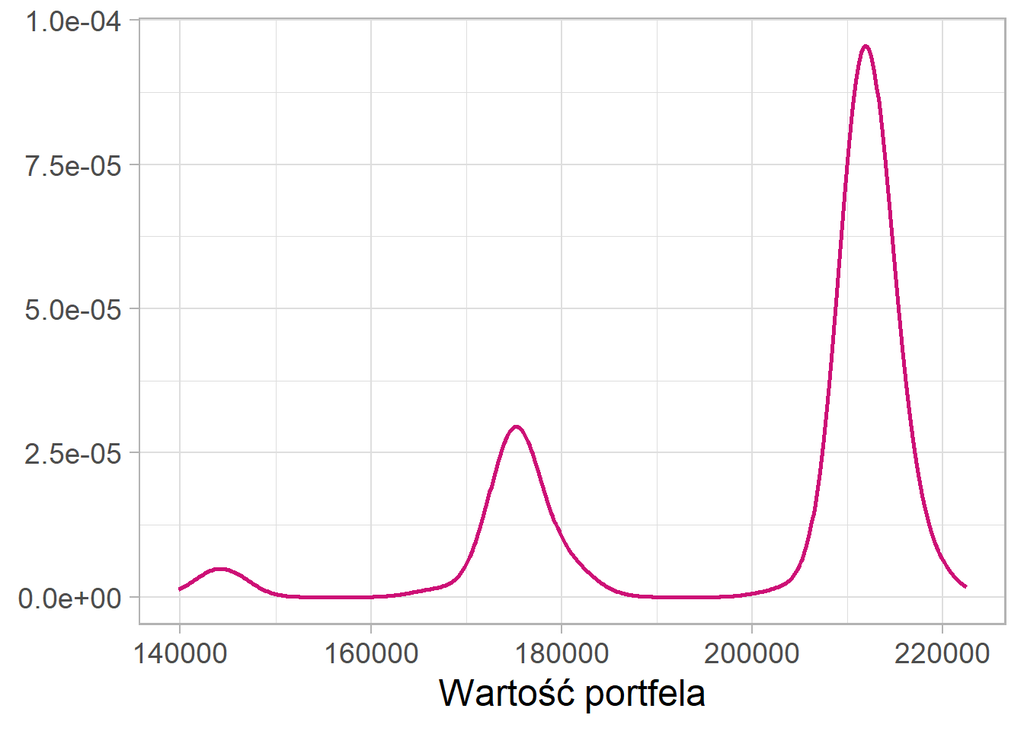

```r
sim3 <-war_portfel(sim2,obligacje, oblVal)

sim3 %>%
  ggplot()+
  geom_density(aes(x = Portfel), size = 1, color = "#CD1076" ) +
theme_light ( base_size = 18)+
  labs(y = NULL, x = "Wartość portfela")
```

## Value at risk, oraz Estimated Shortfall

Ostatecznym krokiem jest wyznaczenie odpowiedniego kwantyla, z zasymulowanego rozkładu. Dla przyjetych założeń w badaniu 99.9% Var i Es wyszły na wysokości:

```r
VaR <- quantile(sim3$Portfel, 0.001)
ES <- mean(sim3$Portfel[sim3$Portfel <=VaR])

wyniki <- data.frame(VaR, ES)
colnames(wyniki) <- c("VaR", "ES")
wyniki
```

|  | VaR | ES |
| --- | --- | --- |
| 0.1% | 143740.8 | 143383.9 |

# Nieskorelowane inwestycje

Następnym krokiem w badaniu jest uzuskanie i omówienie wyników, dla portfela w którym inwestycje nie są ze sobą skorelowane. Ta część badania odowłuje się do pojęcia **dyfersyfikacji ryzyka**.